# Capstone Project - Milestone Report

Alicia Rodriguez

11 May 2017

## Objectives

This report shows the results from the exploratory analysis performed over the three documents conforming the corpora of texts, with which the word prediction model will be built.

## Analysis of the size of the corpora

First, let’s load the data and take a look at the encoding:

```r
#dont know encoding
library(readr)
guess_encoding("./final/en_US/en_US.twitter.txt", n_max=-1)
```

```
##       encoding confidence
## 1        UTF-8       1.00
## 2 windows-1252       0.59
```

```r
#seems to be UTF-8

en_twitter <- read_lines(con <- file("./final/en_US/en_US.twitter.txt", encoding = "UTF-8"))
en_blogs <- read_lines(con <- file("./final/en_US/en_US.blogs.txt", encoding = "UTF-8"))
en_news <- read_lines(con <- file("./final/en_US/en_US.news.txt", encoding = "UTF-8"))

Encoding(en_twitter) <- "UTF-8"
Encoding(en_blogs) <- "UTF-8"
Encoding(en_news) <- "UTF-8"

## Does any line contain non-ASCII characters?
any(grep("I_WAS_NOT_ASCII", iconv(en_twitter, "UTF-8", "ASCII", sub="I_WAS_NOT_ASCII")))
```

```
## [1] TRUE
```

```r
any(grep("I_WAS_NOT_ASCII", iconv(en_blogs, "UTF-8", "ASCII", sub="I_WAS_NOT_ASCII")))
```

```
## [1] TRUE
```

```r
any(grep("I_WAS_NOT_ASCII", iconv(en_news, "UTF-8", "ASCII", sub="I_WAS_NOT_ASCII")))
```

```
## [1] TRUE
```

So we see that the three sources have non-ascii characters, and thus, we need to delete them (the final size of the corpus is clearly bigger when filtering out the non-ascii chars). Let’s create the corpora and make some filtering. We consider:

- Filtering non-ascii chars
- Transforming to lower case to reduce size of dictionary of different words
- Ignoring mispelled words (besides, filtering them takes an extraordinary amount of time). We consider that they will appear much less than the correct version, and thus will be ignored with respect to the correct version (in fact, they may be deleted from the matrix and model, because of the low frequency. More on that on following sections)
- Ignoring URLs (considering that each URL will be almost unique, and thus, unfrequent)
- Numbers could be key in our model. Thus, we replace any number (or combination of numbers, punctuation and letters, e.g., 5.2B or 1920s) by the word NUM
- Stop puctuation (., …, :, ;, ?, !) could be key in our model. Thus, we transform any combination of these signs by the word STOP
- Deleting all other signs
- Ignoring profanity words. We agree on not predicting them, but we think they are part of the speech, and thus, of the text structure on which we are basing our prediction model. Therefore, we intend that profanity words will be part of the model, but we will try to replace its predictions by the next most probable word.

(NOTE. I have used tm package to create the corpus because of its flexibility in transforming the text. However, in order to create the document term frequency matrix, I used quanteda package since it is much faster, and solve my problems when trying to initially analyze the whole corpus).

```r
library(tm)

en_twitter_textDoc <- PlainTextDocument(en_twitter, heading = "en_US_twitter", language = "en")
en_blogs_textDoc <- PlainTextDocument(en_blogs, heading = "en_US_blogs", language = "en")
en_news_textDoc <- PlainTextDocument(en_news, heading = "en_US_news", language = "en")

en_corpus <- c(en_twitter_textDoc, en_blogs_textDoc, en_news_textDoc)
#the previous line replaces the VCorpus( ... ), leveraging the already loaded documents
#en_corpus <- VCorpus(DirSource("./final/en_US/", encoding = "UTF-8"),
#                      readerControl = list(reader = readPlain,
#                                           language = "en_US",
#                                           load = TRUE))
#to inspect content

#en_corpus[[1]]$content[1]

en_corpus <- tm_map(en_corpus, content_transformer(iconv),
                    from = "UTF-8", to = "ASCII", sub = "")
en_corpus <- tm_map(en_corpus, content_transformer(tolower))

en_corpus <- tm_map(en_corpus, content_transformer(gsub),
                    pattern = "[[:alnum:]]*[[:digit:]]+(\\.|,)*[[:digit:]]*[[:alnum:]]*",
                    replacement = " NNUMM ")

en_corpus <- tm_map(en_corpus, content_transformer(gsub), pattern = "[\\.|;|:|\\?|!]+", replacement = " SSTPP ")

#At first, I tried leaving ' and - in the text, but the tokenizer recognizes them
#as separate tokens, so they're deleted too
en_corpus <- tm_map(en_corpus, content_transformer(gsub),
                    pattern = "[^[:alnum:][:space:]]", replacement = "")

en_corpus <- tm_map(en_corpus, stripWhitespace)
```

Let’s try to create the document-term matrix for unigrams and bigrams, using the quanteda package for speed reasons.

```r
#need for installing
#install.packages("Matrix")
#install.packages("quanteda")
#beware of the warnings: need to restart session and rstudio after each installation
library(quanteda)
en_qcorpus <- corpus(en_corpus)
dfm_unigram<-dfm(en_qcorpus)
dfm_bigram<-dfm(en_qcorpus, ngrams=2)

dfm_unigram_size <- format(object.size(dfm_unigram), units = "Mb")
dfm_bigram_size <- format(object.size(dfm_bigram), units = "Mb")
```

Taking a look at the size of the two matrices (61.8 Mb for the unigram case, and 1113 Mb for the bigram case) we can conclude that we cannot use the whole set of lines from the texts, since the size of the model is extremely big (even when ignoring the trigram case). Thus, let’s sample the original data set to obtain a 10% of its contents and compare with the complete case (several % have been tested, and all of them achieved similar results with respect to distribution of frequency of words, thus keeping 10% because the resulting corpora and term-frequency matrices have a reduced size that allows for bounded computing times).

```r
library(tm)
set.seed(12345)
samples_twitter <- rbinom(length(en_twitter), size=1, prob=0.1)
samples_blogs <- rbinom(length(en_blogs), size=1, prob=0.1)
samples_news <- rbinom(length(en_news), size=1, prob=0.1)

en_twitter_sampled <- en_twitter[which(samples_twitter==1)]
en_blogs_sampled <- en_blogs[which(samples_blogs==1)]
en_news_sampled <- en_news[which(samples_news==1)]

en_twitter_sampled_textDoc <- PlainTextDocument(en_twitter_sampled, heading = "en_US_twitter_sampled", language = "en")
en_blogs_sampled_textDoc <- PlainTextDocument(en_blogs_sampled, heading = "en_US_blogs_sampled", language = "en")
en_news_sampled_textDoc <- PlainTextDocument(en_news_sampled, heading = "en_US_news_sampled", language = "en")

en_corpus_sampled <- c(en_twitter_sampled_textDoc, en_blogs_sampled_textDoc, en_news_sampled_textDoc)
en_corpus_sampled <- tm_map(en_corpus_sampled, content_transformer(iconv),
                    from = "UTF-8", to = "ASCII", sub = "")
en_corpus_sampled <- tm_map(en_corpus_sampled, content_transformer(tolower))

en_corpus_sampled <- tm_map(en_corpus_sampled, content_transformer(gsub),
                    pattern = "[[:alnum:]]*[[:digit:]]+(\\.|,)*[[:digit:]]*[[:alnum:]]*",
                    replacement = " NNUMM ")

en_corpus_sampled <- tm_map(en_corpus_sampled, content_transformer(gsub), pattern = "[\\.|;|:|\\?|!]+", replacement = " SSTPP ")

en_corpus_sampled <- tm_map(en_corpus_sampled, content_transformer(gsub),
                    pattern = "[^[:alnum:][:space:]]", replacement = "")

en_corpus_sampled <- tm_map(en_corpus_sampled, stripWhitespace)
```

## Unigram exploratory analysis

First, let’s make a comparison of the sampled and not-sampled versions of the corpus:

| Document | Number lines original | Number lines sampled |
| --- | --- | --- |
| en_twitter | 2360148 | 237131 |
| en_blogs | 899288 | 89820 |
| en_news | 1010242 | 101144 |

And also of the size of the resulting corpora:

| Corpus | Size |
| --- | --- |
| en_corpus | 824.3 Mb |
| en_corpus_sampled | 83.3 Mb |

Now, let’s extract the unigrams:

```r
#need for installing
#install.packages("Matrix")
#install.packages("quanteda")
#beware of the warnings: need to restart session and rstudio after each installation
library(quanteda)
en_qcorpus_sampled <- corpus(en_corpus_sampled)
dfm_unigram_sampled<-dfm(en_qcorpus_sampled)
dfm_bigram_sampled<-dfm(en_qcorpus_sampled, ngrams=2)
dfm_trigram_sampled<-dfm(en_qcorpus_sampled, ngrams=3)

dfm_unigram_size_sampled <- format(object.size(dfm_unigram_sampled), units = "Mb")
dfm_bigram_size_sampled <- format(object.size(dfm_bigram_sampled), units = "Mb")
dfm_trigram_size_sampled <- format(object.size(dfm_trigram_sampled), units = "Mb")
```

| Matrix | Size |
| --- | --- |
| dfm_unigram | 61.8 Mb |
| dfm_unigram_sampled | 15.7 Mb |
| dfm_bigram | 1113 Mb |
| dfm_bigram_sampled | 208.7 Mb |
| dfm_trigram_sampled | 585.5 Mb |

and perform some exploraroty analysis on the results:

```r
#Convert to matrix to easily operate over it
freqWordsSource <- as.matrix(dfm_unigram)
freqWordsSource_sampled <- as.matrix(dfm_unigram_sampled)

#Number of words per source
numberWordsSource <- data.frame(twitter = sum(freqWordsSource[1,]),
                              twitter_sampled = sum(freqWordsSource_sampled[1,]),
                              blogs = sum(freqWordsSource[2,]),
                              blogs_sampled = sum(freqWordsSource_sampled[2,]),
                              news = sum(freqWordsSource[3,]),
                              news_sampled = sum(freqWordsSource_sampled[3,]))
numberWordsSource
```

```
##    twitter twitter_sampled    blogs blogs_sampled     news news_sampled
## 1 33610970         3377497 39705707       3967521 36707263      3680601
```

```r
numberWords = numberWordsSource$twitter + numberWordsSource$blogs + numberWordsSource$news
numberWords_sampled = numberWordsSource$twitter_sampled + numberWordsSource$blogs_sampled + numberWordsSource$news_sampled

#dictionary length
distinctWordsSource <- data.frame(twitter = sum(freqWordsSource[1,]>0),
                            twitter_sampled = sum(freqWordsSource_sampled[1,]>0),
                            blogs = sum(freqWordsSource[2,]>0),
                            blogs_sampled = sum(freqWordsSource_sampled[2,]>0),
                            news = sum(freqWordsSource[3,]>0),
                            news_sampled = sum(freqWordsSource_sampled[3,]>0))
distinctWordsSource
```

```
##   twitter twitter_sampled  blogs blogs_sampled   news news_sampled
## 1  383616           94671 370294        101081 306381        99094
```

```r
#most common words
twitterWordsFreq<-sort(freqWordsSource[1,], decreasing=TRUE)
blogsWordsFreq<-sort(freqWordsSource[2,], decreasing=TRUE)
newsWordsFreq<-sort(freqWordsSource[3,], decreasing=TRUE)

twitterWordsFreq_sampled<-sort(freqWordsSource_sampled[1,], decreasing=TRUE)
blogsWordsFreq_sampled<-sort(freqWordsSource_sampled[2,], decreasing=TRUE)
newsWordsFreq_sampled<-sort(freqWordsSource_sampled[3,], decreasing=TRUE)

mostCommonWords <- data.frame(twitter = names(twitterWordsFreq[1:20]),
                              twitter_sampled = names(twitterWordsFreq_sampled[1:20]),
                              blogs = names(blogsWordsFreq[1:20]),
                              blogs_sampled = names(blogsWordsFreq_sampled[1:20]),
                              news = names(newsWordsFreq[1:20]),
                              news_sampled = names(newsWordsFreq_sampled[1:20]))
mostCommonWords
```

```
##    twitter twitter_sampled blogs blogs_sampled  news news_sampled
## 1    sstpp           sstpp sstpp         sstpp sstpp        sstpp
## 2      the             the   the           the   the          the
## 3       to              to   and           and nnumm        nnumm
## 4        i               i    to            to    to           to
## 5        a               a     a             a     a            a
## 6    nnumm           nnumm    of            of   and          and
## 7      you             you     i             i    of           of
## 8      and             and    in            in    in           in
## 9      for             for nnumm         nnumm   for          for
## 10      in              in  that          that  that         that
## 11      of              is    is            is    is           is
## 12      is              of    it            it    on           on
## 13      it              my   for           for  with         with
## 14      my              it   you           you  said         said
## 15      on              on  with          with   was          was
## 16    that            that   was           was    he           he
## 17      me              me    on            on    it           it
## 18      be              at    my            my    at           at
## 19      at              be  this          this    as           as
## 20    with            with    as            as     i            i
```

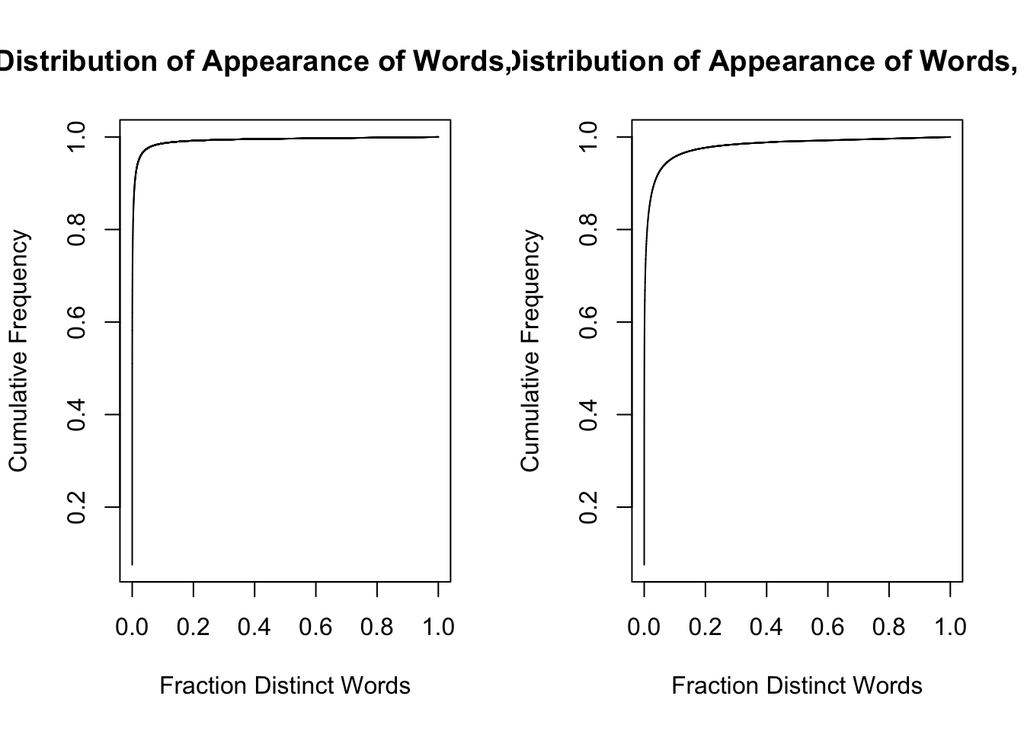

```r
#Frequency of words
freqWords = sort(colSums(freqWordsSource), decreasing=TRUE)
freqWords_sampled = sort(colSums(freqWordsSource_sampled), decreasing=TRUE)

cumsumfreq <- cumsum(freqWords)
cumsumfreq_sampled <- cumsum(freqWords_sampled)

par(mfrow=c(1,2))
plot(x=((1:length(cumsumfreq))/length(cumsumfreq)),y=(cumsumfreq/numberWords), type = "l",
     main = "Cumulative Distribution of Appearance of Words, Original Corpus",
     xlab = "Fraction Distinct Words", ylab = "Cumulative Frequency")
plot(x=((1:length(cumsumfreq_sampled))/length(cumsumfreq_sampled)),y=(cumsumfreq_sampled/numberWords_sampled), type = "l", main = "Cumulative Distribution of Appearance of Words, Sampled Corpus",
     xlab = "Fraction Distinct Words", ylab = "Cumulative Frequency")
```

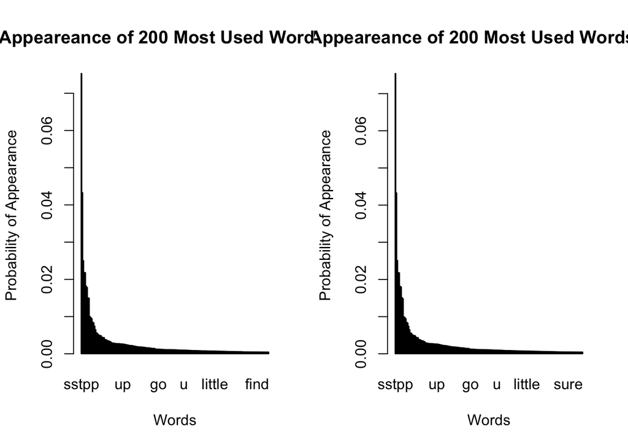

```r
par(mfrow=c(1,2))
barplot(height = freqWords[1:200]/numberWords,
        main = "Probability of Appeareance of 200 Most Used Words, Original Corpus",
        xlab = "Words", ylab = "Probability of Appearance")
barplot(height = freqWords_sampled[1:200]/numberWords_sampled,
        main = "Probability of Appeareance of 200 Most Used Words, Sampled Corpus",
        xlab = "Words", ylab = "Probability of Appearance")
```

## Bigrams and Trigram Analysis

Taking the sampled version of the data, let’s see the distribution of bigrams and trigrams.

```r
#Convert to matrix to easily operate over it
bigramsSource_sampled <- as.matrix(dfm_bigram_sampled)

#Number of words per source
numberBigramsSource <- data.frame(twitter = sum(bigramsSource_sampled[1,]),
                              blogs = sum(bigramsSource_sampled[2,]),
                              news = sum(bigramsSource_sampled[3,]))
numberBigramsSource
```

```
##   twitter   blogs    news
## 1 3377496 3967520 3680600
```

```r
numberBigrams = numberBigramsSource$twitter + numberBigramsSource$blogs + numberBigramsSource$news

#dictionary length
distinctBigramsSource <- data.frame(twitter = sum(bigramsSource_sampled[1,]>0),
                            blogs = sum(bigramsSource_sampled[2,]>0),
                            news = sum(bigramsSource_sampled[3,]>0))
distinctBigramsSource
```

```
##   twitter   blogs    news
## 1  905631 1121541 1142969
```

```r
#most common words
twitterBigramsFreq<-sort(bigramsSource_sampled[1,], decreasing=TRUE)
blogsBigramsFreq<-sort(bigramsSource_sampled[2,], decreasing=TRUE)
newsBigramsFreq<-sort(bigramsSource_sampled[3,], decreasing=TRUE)

mostCommonBigrams <- data.frame(twitter = names(twitterBigramsFreq[1:20]),
                              blogs = names(blogsBigramsFreq[1:20]),
                              news = names(newsBigramsFreq[1:20]))
mostCommonBigrams
```

```
##         twitter       blogs        news
## 1       sstpp_i     sstpp_i   sstpp_the
## 2   sstpp_sstpp      of_the      of_the
## 3   sstpp_nnumm   sstpp_the      in_the
## 4        in_the      in_the nnumm_nnumm
## 5       for_the      to_the sstpp_nnumm
## 6   nnumm_sstpp sstpp_nnumm  said_sstpp
## 7      sstpp_im      on_the      to_the
## 8      it_sstpp       to_be      on_the
## 9      rt_sstpp   sstpp_and     for_the
## 10    you_sstpp    sstpp_it     sstpp_i
## 11    sstpp_the     and_the    sstpp_he
## 12       of_the nnumm_nnumm nnumm_sstpp
## 13    sstpp_you     for_the      at_the
## 14 sstpp_thanks   sstpp_but   sstpp_but
## 15     sstpp_rt  sstpp_this     and_the
## 16  nnumm_nnumm      i_have        in_a
## 17    sstpp_its       i_was    in_nnumm
## 18       on_the       and_i   the_nnumm
## 19        to_be      at_the       to_be
## 20     sstpp_we       it_is    sstpp_it
```

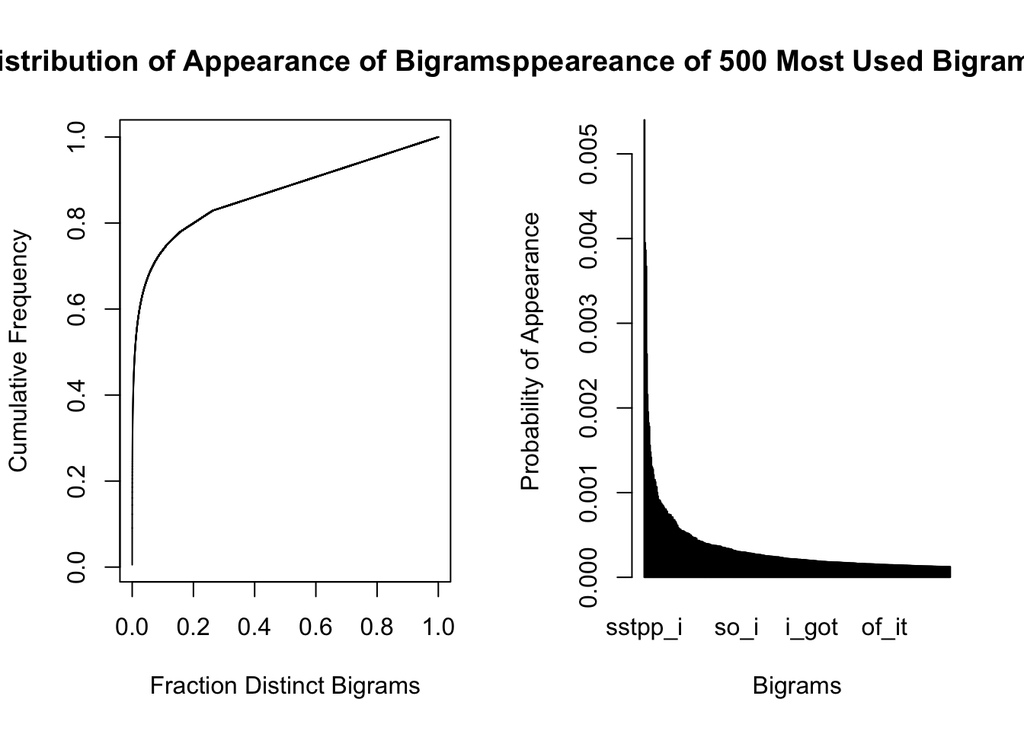

```r
#Frequency of words
freqBigrams = sort(colSums(bigramsSource_sampled), decreasing=TRUE)

cumsumFreqBigrams <- cumsum(freqBigrams)

par(mfrow=c(1,2))
plot(x=((1:length(cumsumFreqBigrams))/length(cumsumFreqBigrams)),
     y=(cumsumFreqBigrams/numberBigrams), type = "l",
     main = "Cumulative Distribution of Appearance of Bigrams, Sampled Corpus",
     xlab = "Fraction Distinct Bigrams", ylab = "Cumulative Frequency")

barplot(height = freqBigrams[1:500]/numberBigrams,
        main = "Probability of Appeareance of 500 Most Used Bigrams, Sampled Corpus",
        xlab = "Bigrams", ylab = "Probability of Appearance")
```

```r
#Convert to matrix to easily operate over it
trigramsSource_sampled <- as.matrix(dfm_trigram_sampled)

#Number of words per source
numberTrigramsSource <- data.frame(twitter = sum(trigramsSource_sampled[1,]),
                              blogs = sum(trigramsSource_sampled[2,]),
                              news = sum(trigramsSource_sampled[3,]))
numberTrigramsSource
```

```
##   twitter   blogs    news
## 1 3377495 3967519 3680599
```

```r
numberTrigrams = numberTrigramsSource$twitter + numberTrigramsSource$blogs + numberTrigramsSource$news

#dictionary length
distinctTrigramsSource <- data.frame(twitter = sum(trigramsSource_sampled[1,]>0),
                            blogs = sum(trigramsSource_sampled[2,]>0),
                            news = sum(trigramsSource_sampled[3,]>0))
distinctTrigramsSource
```

```
##   twitter   blogs    news
## 1 2169823 2684448 2584829
```

```r
#most common words
twitterTrigramsFreq<-sort(trigramsSource_sampled[1,], decreasing=TRUE)
blogsTrigramsFreq<-sort(trigramsSource_sampled[2,], decreasing=TRUE)
newsTrigramsFreq<-sort(trigramsSource_sampled[3,], decreasing=TRUE)

mostCommonTrigrams <- data.frame(twitter = names(twitterTrigramsFreq[1:20]),
                              blogs = names(blogsTrigramsFreq[1:20]),
                              news = names(newsTrigramsFreq[1:20]))
mostCommonTrigrams
```

```
##               twitter             blogs              news
## 1      sstpp_rt_sstpp nnumm_sstpp_nnumm nnumm_nnumm_nnumm
## 2    sstpp_thanks_for      sstpp_i_have     sstpp_m_sstpp
## 3      thanks_for_the      sstpp_it_was nnumm_sstpp_nnumm
## 4   nnumm_sstpp_nnumm       sstpp_it_is     sstpp_s_sstpp
## 5     sstpp_thank_you     sstpp_this_is         u_sstpp_s
## 6        sstpp_i_love        one_of_the         p_sstpp_m
## 7       sstpp_i_think        sstpp_i_am     nnumm_p_sstpp
## 8          sstpp_i_am       sstpp_i_was     he_said_sstpp
## 9        sstpp_i_have nnumm_nnumm_nnumm sstpp_nnumm_nnumm
## 10       sstpp_i_dont          a_lot_of        one_of_the
## 11       sstpp_if_you      sstpp_if_you   more_than_nnumm
## 12       sstpp_i_just sstpp_nnumm_nnumm     nnumm_a_sstpp
## 13    thank_you_sstpp      sstpp_i_dont         a_sstpp_m
## 14     at_nnumm_sstpp     sstpp_i_think          a_lot_of
## 15  nnumm_nnumm_nnumm      sstpp_in_the      sstpp_it_was
## 16  sstpp_nnumm_sstpp        as_well_as       the_u_sstpp
## 17 sstpp_thanks_sstpp       sstpp_i_had    nnumm_to_nnumm
## 18    right_now_sstpp        out_of_the sstpp_nnumm_sstpp
## 19      sstpp_sstpp_i sstpp_nnumm_sstpp nnumm_nnumm_sstpp
## 20      thank_you_for       some_of_the     sstpp_nnumm_p
```

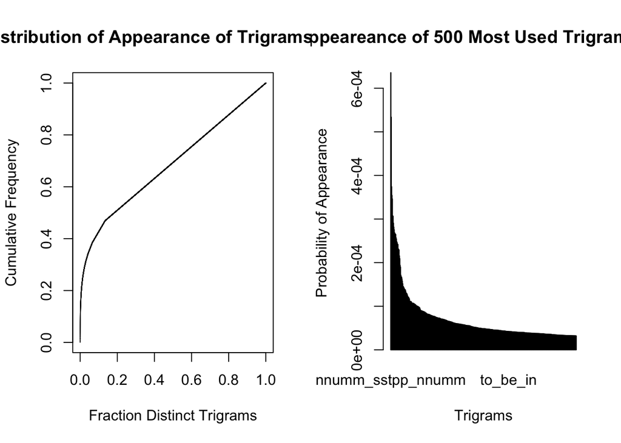

```r
#Frequency of words
freqTrigrams = sort(colSums(trigramsSource_sampled), decreasing=TRUE)

cumsumFreqTrigrams <- cumsum(freqTrigrams)

par(mfrow=c(1,2))
plot(x=((1:length(cumsumFreqTrigrams))/length(cumsumFreqTrigrams)),
     y=(cumsumFreqTrigrams/numberTrigrams), type = "l",
     main = "Cumulative Distribution of Appearance of Trigrams, Sampled Corpus",
     xlab = "Fraction Distinct Trigrams", ylab = "Cumulative Frequency")

barplot(height = freqTrigrams[1:500]/numberTrigrams,
        main = "Probability of Appeareance of 500 Most Used Trigrams, Sampled Corpus",
        xlab = "Trigrams", ylab = "Probability of Appearance")
```